# QTM 151 - Quiz 5

## Try to submit as an HTML file

Print your name below

```python
# Write your answer here

print("Abby Brickman")
```

```
Abby Brickman
```

This quiz is open book

- You can use the lecture notes
- You will get partial credit for attempting the questions
- To get full credit, the code should run as intended
- You should NOT communicate with other students

Write the following message as a comment:

"I will abide by Emory's code of conduct"

```python
# Write your own code

# I will abide by Emory's code of conduct
```

Import the libraries "matplotlib.pyplot" and "pandas"

```python
# Write your answer here

import pandas as pd
import matplotlib.pyplot as plt
import matplotlib.dates as mdates
from datetime import date, time, datetime
```

In this quiz, we will work with a World Bank  
dataset on the proportion of urban population across  
countries, from 2016-2020.

- This is an example of a "panel"/"longitudinal" dataset  
  which contains information about the same unit (country)  
  over time.
  - This is in "long" format (see Lecture 22)

(a) Import and parse dates

- Import "data_raw/wdi_long.csv"
- Create a new column called "date" which uses `pd.to_datetime(...,format = ...)`  
  to convert year to a date format
- To get full points use wild cards to establish the format. To get full points,  
  set the "format" option using wildcards as in Lecture 20.

```python
# Write your own code
wdi_long = pd.read_csv("data_raw/wdi_long.csv")
wdi_long["date"] = pd.to_datetime(wdi_long["year"], format = "%Y")
display(wdi_long["date"])
```

```
0      2016-01-01
1      2016-01-01
2      2016-01-01
3      2016-01-01
4      2016-01-01
          ...
1080   2020-01-01
1081   2020-01-01
1082   2020-01-01
1083   2020-01-01
1084   2020-01-01
Name: date, Length: 1085, dtype: datetime64[ns]
```

(b) Plot multiple time series

- Sort `wdi_long` by `country_name` and `year` in ascending order.  
  Call this new dataset, `wdi_sorted`

HINT: See Lecture 10a for how to sort. You can sort by multiple  
variables by entering them as a list `[[...]]`

NOTE: Sorting is very important when using time series data,  
particularly for plotting and data cleaning, since observations are ordered  
in sequence from earliest to latest.

```python
# Write your own code
wdi_sorted = wdi_long.sort_values(by = ["year", "country_name"], ascending = True)
display(wdi_sorted)
```

|  | year | year_code | country_name | country_code | prop_urban | date |
| --- | --- | --- | --- | --- | --- | --- |
| 0 | 2016 | YR2016 | Afghanistan | AFG | 25.020 | 2016-01-01 |
| 1 | 2016 | YR2016 | Albania | ALB | 58.421 | 2016-01-01 |
| 2 | 2016 | YR2016 | Algeria | DZA | 71.459 | 2016-01-01 |
| 3 | 2016 | YR2016 | American Samoa | ASM | 87.198 | 2016-01-01 |
| 4 | 2016 | YR2016 | Andorra | AND | 88.248 | 2016-01-01 |
| ... | ... | ... | ... | ... | ... | ... |
| 1080 | 2020 | YR2020 | Virgin Islands (U.S.) | VIR | 95.939 | 2020-01-01 |
| 1081 | 2020 | YR2020 | West Bank and Gaza | PSE | 76.719 | 2020-01-01 |
| 1082 | 2020 | YR2020 | Yemen, Rep. | YEM | 37.908 | 2020-01-01 |
| 1083 | 2020 | YR2020 | Zambia | ZMB | 44.629 | 2020-01-01 |
| 1084 | 2020 | YR2020 | Zimbabwe | ZWE | 32.242 | 2020-01-01 |

1085 rows × 6 columns

(c) Flag subset of data and plot

- For the sorted dataset, subset all entries of `wdi_sorted` from part (b)  
  where `country_name` to equal `"United States"` using `.query()`.  
  Call this new dataset `wdi_usa`
- Create a line plot with year on the x-axis and `prop_urban` on the y-axis
- Label the x-axis, the y-axis, and the title

HINT: You can use `.query()` to subset to "United States" by using  
escape characters, e.g. `country_name == \"United States\"`.  
See Lecture 10a for how to use query.

|  | year | year_code | country_name | country_code | prop_urban | date |
| --- | --- | --- | --- | --- | --- | --- |
| 206 | 2016 | YR2016 | United States | USA | 81.862 | 2016-01-01 |
| 423 | 2017 | YR2017 | United States | USA | 82.058 | 2017-01-01 |
| 640 | 2018 | YR2018 | United States | USA | 82.256 | 2018-01-01 |
| 857 | 2019 | YR2019 | United States | USA | 82.459 | 2019-01-01 |
| 1074 | 2020 | YR2020 | United States | USA | 82.664 | 2020-01-01 |

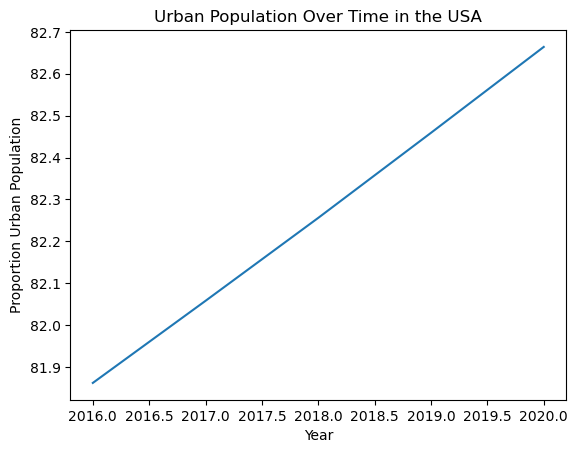

```python
# Write your own code
wdi_usa = wdi_sorted.query('country_name == "United States"')
display(wdi_usa)
plt.plot("year", "prop_urban", data = wdi_usa)
plt.xlabel('Year')
plt.ylabel('Proportion Urban Population')
plt.title('Urban Population Over Time in the USA')
```

(d) Obtain yearly growth rates by country

- For this question you will use `wdi_sorted` that you created in part (b)
- Use `.groupby()`, `.diff()`, and `.shift()` to compute  
  the yearly growth rates in the urban population by country.
- Store your results in a new column of `wdi_sorted` called  
  `growth_prop_urban`.

HINT: See Lecture 22

```python
# Write your own code
wdi_grouped = wdi_sorted.groupby("country_name")
wdi_sorted["wdi_diff"] = wdi_grouped["prop_urban"].diff()
wdi_sorted["wdi_shift"] = wdi_grouped["prop_urban"].shift(1)
wdi_sorted["growth_prop_urban"] = (wdi_sorted["wdi_diff"]/wdi_sorted["wdi_shift"])* 100
```

(e) Obtain average yearly growth rates

- This question follows-up to part (d).
- Use `.groupby()`, `.agg()` to compute the average of `growth_prop_urban`

HINT: See Lecture 14 for how to compute grouped statistics.

```python
# Write your own code

wdi_sorted.groupby("country_name").agg(mean_growth = ('growth_prop_urban', 'mean'))
```

| country_name | mean_growth |
| --- | --- |
| Afghanistan | 0.990398 |
| Albania | 1.543412 |
| Algeria | 0.786245 |
| American Samoa | -0.012903 |
| Andorra | -0.094185 |
| ... | ... |
| Virgin Islands (U.S.) | 0.119966 |
| West Bank and Gaza | 0.358712 |
| Yemen, Rep. | 1.730298 |
| Zambia | 1.266444 |
| Zimbabwe | -0.041772 |

217 rows × 1 columns

(f) Convert dataset to wide format

- Convert "wdi_sorted" from long to wide, using the following arguments:

  ```
   index = 'country_name'
   columns = 'year'
   values =  'prop_urban'
  ```

- Display the dataset to check that it is in wide format

HINT: See Lecture 22 for details on how to use `pd.pivot()`

```python
# Write your own code

financial_wide = (pd.pivot(wdi_long,
                           index = 'country_name',
                           columns = 'year',
                           values =  'prop_urban'))
display(financial_wide)
```

| year country_name | 2016 | 2017 | 2018 | 2019 | 2020 |
| --- | --- | --- | --- | --- | --- |
| Afghanistan | 25.020 | 25.250 | 25.495 | 25.754 | 26.026 |
| Albania | 58.421 | 59.383 | 60.319 | 61.229 | 62.112 |
| Algeria | 71.459 | 72.052 | 72.629 | 73.189 | 73.733 |
| American Samoa | 87.198 | 87.170 | 87.153 | 87.147 | 87.153 |
| Andorra | 88.248 | 88.150 | 88.062 | 87.984 | 87.916 |
| ... | ... | ... | ... | ... | ... |
| Virgin Islands (U.S.) | 95.480 | 95.603 | 95.721 | 95.832 | 95.939 |
| West Bank and Gaza | 75.628 | 75.894 | 76.164 | 76.440 | 76.719 |
| Yemen, Rep. | 35.394 | 36.016 | 36.642 | 37.273 | 37.908 |
| Zambia | 42.438 | 42.976 | 43.521 | 44.072 | 44.629 |
| Zimbabwe | 32.296 | 32.237 | 32.209 | 32.210 | 32.242 |

217 rows × 5 columns